# Neighborhood analyses - Interaction Changed Features

```r
date()
```

```
## [1] "Fri Oct 31 16:59:55 2025"
```

```r
library(Giotto)
library(future); if(parallelly::availableCores() > 2 )  # & .Platform$OS.type == "windows")
  {plan('multisession', workers = parallelly::availableCores()-2)}
options(future.globals.maxSize= 1e12)
library(scran); library(MAST); # library(leiden);   # library(multinet);
library(data.table)
```

```r
library(gplots); library(ggplot2); library(viridis)
library(dbscan)
library(dplyr); library(leidenAlg)
library(ComplexHeatmap)
library(circlize)
library(dplyr); library(tidyr)
set.seed(43)
knitr::opts_chunk$set(fig.retina = 2)
```

```r
#  ****** libraries to install
# library(factoextra)
```

# 1 read in data object

```r
sln <- readRDS("sln.clustering5.annot.spatnet.20250617.160512.RDS")
gc()
```

```
##              used    (Mb) gc trigger    (Mb)   max used    (Mb)
## Ncells   21584414  1152.8   34795370  1858.3   21587936  1153.0
## Vcells 4270363625 32580.3 5441389056 41514.6 4270383586 32580.5
```

```r
md <- pDataDT(sln)
stableColorsL2 <- getDistinctColors(length(unique(md$L2_annotations)));  names(stableColorsL2) <- unique(md$L2_annotations)
stage3.subgroup <- c("tumor.1","tumor.2","tumor.3","tumor.4","tumor.5","tumor.6","tumor.7", "tumor.8",
                                                 "tumor.9","tumor.10")
stage1.subgroup <- c("ctrl.1","ctrl.2","ctrl.3","ctrl.4","ctrl.5")
recur.subgroup <- c("tumor.3","tumor.4","tumor.5","tumor.7","tumor.8","tumor.10")
norecur.subgroup <- c("tumor.1","tumor.2", "tumor.6", "tumor.9")
saveRDS(md, file = "md.RDS")
```

# 2 calculate ICF

```r
list_ID <- unique(md$list_ID)
icf.persample <- list(); icf.persample.enrich <- list()
proteinsList <- c("BCA1", "CD3E", "CD4","CD8" ,"CD11C" ,"CD27","CD38","CD39", "CD45RO","CXCR3","CXCR5",
                  "FOXP3" , "GZMB" ,"HLA.DR", "ICOS","IFNG","IRF4","IRF7","KI67", "LAG3",
                  "PD1","PDL1","STAT1","STAT3","TCF1","TOX" ) # "TBET","PMTOR","CD19","CD20" ,"CD21","MAC2/GAL3","PAX5","VIMENTIN"
timeStamp <- format(Sys.time(), "%m%d.%H%M")
enrich.celltypes <- c("ACTIVATED_TREG", "TCF1_LO_TOX_HI_CD8", "ACTIVATED_CD8") # make a version that keeps all of these cells
```

```r
for (i in list_ID)
{
  if( .Platform$OS.type != "windows")    {    cat(paste("Starting on: ", i, " on ", date(),"\n"),
                                                  file = paste0("progress.",timeStamp,".txt"), append = T)   }
  keepCells <- subset(md, list_ID %in% i )
  sln.sm <- subsetGiotto(gobject = sln, cell_ids = keepCells$cell_ID)
  sln.sm <- createSpatialKNNnetwork(sln.sm, k=9, verbose=T, name = "spatialknn.k9.persample")
  print("made spatialKNN")
  print(getSpatialNetwork(sln.sm))
  res <- findInteractionChangedFeats(gobject = sln.sm, selected_feats = proteinsList,
                                     spatial_network_name = "spatialknn.k9.persample",
                                     cluster_column = "L2_annotations", diff_test = 'permutation',
                                     adjust_method = 'fdr', nr_permutations = 1, do_parallel = T)
  res$list_ID <- i
  icf.persample[i] <- res
  print(paste("Random downsample process for", i, "ends at", date()))
}
```

```
## Setting spatial network [cell] spatialknn.k9.persample
```

```
## [1] "made spatialKNN"
## An object of class spatialNetworkObj : "spatialknn.k5"
## Contains spatial network generated with: dbscan
## spat_unit : "cell"
## provenance: cell
##    1404496 connections (filtered)
```

```
## Newer devel version of GiottoClass on GitHub: 0.4.10
```

```
## Giotto Suite 4.2.2
```

```
## Newer devel version of GiottoClass on GitHub: 0.4.10
```

```
## Giotto Suite 4.2.2
```

```
## Newer devel version of GiottoClass on GitHub: 0.4.10
```

```
## Giotto Suite 4.2.2
```

```
## [1] "Random downsample process for ctrl.1 ends at Fri Oct 31 17:10:46 2025"
```

```
## Setting spatial network [cell] spatialknn.k9.persample
```

```
## [1] "made spatialKNN"
## An object of class spatialNetworkObj : "spatialknn.k5"
## Contains spatial network generated with: dbscan
## spat_unit : "cell"
## provenance: cell
##    310233 connections (filtered)
```

```
## [1] "Random downsample process for tumor.4 ends at Fri Oct 31 17:13:12 2025"
```

```
## Setting spatial network [cell] spatialknn.k9.persample
```

```
## [1] "made spatialKNN"
## An object of class spatialNetworkObj : "spatialknn.k5"
## Contains spatial network generated with: dbscan
## spat_unit : "cell"
## provenance: cell
##    746026 connections (filtered)
```

```
## [1] "Random downsample process for tumor.5 ends at Fri Oct 31 17:17:45 2025"
```

```
## Setting spatial network [cell] spatialknn.k9.persample
```

```
## [1] "made spatialKNN"
## An object of class spatialNetworkObj : "spatialknn.k5"
## Contains spatial network generated with: dbscan
## spat_unit : "cell"
## provenance: cell
##    2062659 connections (filtered)
```

```
## [1] "Random downsample process for ctrl.2 ends at Fri Oct 31 17:25:00 2025"
```

```
## Setting spatial network [cell] spatialknn.k9.persample
```

```
## [1] "made spatialKNN"
## An object of class spatialNetworkObj : "spatialknn.k5"
## Contains spatial network generated with: dbscan
## spat_unit : "cell"
## provenance: cell
##    1888081 connections (filtered)
```

```
## [1] "Random downsample process for tumor.7 ends at Fri Oct 31 17:32:03 2025"
```

```
## Setting spatial network [cell] spatialknn.k9.persample
```

```
## [1] "made spatialKNN"
## An object of class spatialNetworkObj : "spatialknn.k5"
## Contains spatial network generated with: dbscan
## spat_unit : "cell"
## provenance: cell
##    5487423 connections (filtered)
```

```
## [1] "Random downsample process for tumor.6 ends at Fri Oct 31 17:44:18 2025"
```

```
## Setting spatial network [cell] spatialknn.k9.persample
```

```
## [1] "made spatialKNN"
## An object of class spatialNetworkObj : "spatialknn.k5"
## Contains spatial network generated with: dbscan
## spat_unit : "cell"
## provenance: cell
##    2865975 connections (filtered)
```

```
## [1] "Random downsample process for tumor.8 ends at Fri Oct 31 17:52:25 2025"
```

```
## Setting spatial network [cell] spatialknn.k9.persample
```

```
## [1] "made spatialKNN"
## An object of class spatialNetworkObj : "spatialknn.k5"
## Contains spatial network generated with: dbscan
## spat_unit : "cell"
## provenance: cell
##    2570758 connections (filtered)
```

```
## [1] "Random downsample process for ctrl.3 ends at Fri Oct 31 18:00:31 2025"
```

```
## Setting spatial network [cell] spatialknn.k9.persample
```

```
## [1] "made spatialKNN"
## An object of class spatialNetworkObj : "spatialknn.k5"
## Contains spatial network generated with: dbscan
## spat_unit : "cell"
## provenance: cell
##    2593986 connections (filtered)
```

```
## [1] "Random downsample process for tumor.9 ends at Fri Oct 31 18:08:53 2025"
```

```
## Setting spatial network [cell] spatialknn.k9.persample
```

```
## [1] "made spatialKNN"
## An object of class spatialNetworkObj : "spatialknn.k5"
## Contains spatial network generated with: dbscan
## spat_unit : "cell"
## provenance: cell
##    2601274 connections (filtered)
```

```
## [1] "Random downsample process for tumor.10 ends at Fri Oct 31 18:16:38 2025"
```

```
## Setting spatial network [cell] spatialknn.k9.persample
```

```
## [1] "made spatialKNN"
## An object of class spatialNetworkObj : "spatialknn.k5"
## Contains spatial network generated with: dbscan
## spat_unit : "cell"
## provenance: cell
##    1766731 connections (filtered)
```

```
## [1] "Random downsample process for ctrl.4 ends at Fri Oct 31 18:23:43 2025"
```

```
## Setting spatial network [cell] spatialknn.k9.persample
```

```
## [1] "made spatialKNN"
## An object of class spatialNetworkObj : "spatialknn.k5"
## Contains spatial network generated with: dbscan
## spat_unit : "cell"
## provenance: cell
##    1466196 connections (filtered)
```

```
## [1] "Random downsample process for ctrl.5 ends at Fri Oct 31 18:29:26 2025"
```

```
## Setting spatial network [cell] spatialknn.k9.persample
```

```
## [1] "made spatialKNN"
## An object of class spatialNetworkObj : "spatialknn.k5"
## Contains spatial network generated with: dbscan
## spat_unit : "cell"
## provenance: cell
##    534714 connections (filtered)
```

```
## [1] "Random downsample process for tumor.1 ends at Fri Oct 31 18:32:34 2025"
```

```
## Setting spatial network [cell] spatialknn.k9.persample
```

```
## [1] "made spatialKNN"
## An object of class spatialNetworkObj : "spatialknn.k5"
## Contains spatial network generated with: dbscan
## spat_unit : "cell"
## provenance: cell
##    2950573 connections (filtered)
```

```
## [1] "Random downsample process for tumor.2 ends at Fri Oct 31 18:41:00 2025"
```

```
## Setting spatial network [cell] spatialknn.k9.persample
```

```
## [1] "made spatialKNN"
## An object of class spatialNetworkObj : "spatialknn.k5"
## Contains spatial network generated with: dbscan
## spat_unit : "cell"
## provenance: cell
##    3001695 connections (filtered)
```

```
## [1] "Random downsample process for tumor.3 ends at Fri Oct 31 18:49:47 2025"
```

```r
saveRDS(icf.persample, file = "neighborhood.ICFlist.perSample.sln.clustering5.spatnet.RDS")
icf.persample <- purrr::list_rbind(icf.persample, names_to = "list_ID")
# Job Wall-clock time: 01:51:30              Memory Utilized: 72.67 GB
```

# 3 load ICF data

```r
icf.persample <- purrr::list_rbind(readRDS(file="neighborhood.ICFlist.perSample.sln.clustering5.spatnet.RDS"),
                                    names_to = "list_ID")

 #    list_ID  feats       sel     other     log2fc        diff p.value p.adj  perm_sel perm_other perm_log2fc   perm_diff
 #     <char> <char>     <num>     <num>      <num>       <num>   <num> <num>     <num>      <num>       <num>       <num>
 # 1:  ctrl.1    CD4  6.678378  4.273293  0.6322200   2.4050848       0     0  4.443401   4.591068 -0.04614361 -0.14766649
 # 2:  ctrl.1   IRF7  4.335566  2.802213  0.6119648   1.5333530       0     0  2.833045   3.015845 -0.08722451 -0.18280052
 # 3:  ctrl.1 HLA.DR  7.155213  4.690167  0.5989422   2.4650466       0     0  5.143791   4.976156  0.04687391  0.16763547
 #                  cell_type             int_cell_type nr_select int_nr_select nr_other int_nr_other
 #                   <char>                    <char>     <int>         <int>    <int>        <int>
 # 1: TCF1_MIXED_TOX_HI_CD8        TCF1_HI_TOX_HI_CD8       271           309     1906         1054
 # 2: TCF1_MIXED_TOX_HI_CD8        TCF1_HI_TOX_HI_CD8       271           309     1906         1054
 # 3: TCF1_MIXED_TOX_HI_CD8        TCF1_HI_TOX_HI_CD8       271           309     1906         1054
 #                                          unif_int                                  spec_int type_int
 #                                       <char>                                    <char>   <char>
 # 1: TCF1_HI_TOX_HI_CD8--TCF1_MIXED_TOX_HI_CD8 TCF1_MIXED_TOX_HI_CD8--TCF1_HI_TOX_HI_CD8   hetero
 # 2: TCF1_HI_TOX_HI_CD8--TCF1_MIXED_TOX_HI_CD8 TCF1_MIXED_TOX_HI_CD8--TCF1_HI_TOX_HI_CD8   hetero
 # 3: TCF1_HI_TOX_HI_CD8--TCF1_MIXED_TOX_HI_CD8 TCF1_MIXED_TOX_HI_CD8--TCF1_HI_TOX_HI_CD8   hetero
```

# 4 make volcano plots

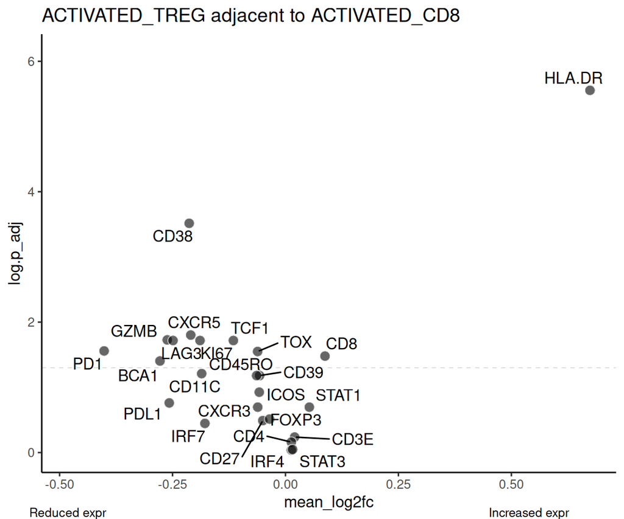

| feats | mean_sel | mean_other | mean_log2fc | p_value | Welch_t | p_adj | log.p_adj | highlight.feat | 50% |
| --- | --- | --- | --- | --- | --- | --- | --- | --- | --- |
| PD1 | 1.774493 | 2.197256 | -0.40142435 | 9.574644e-03 | -2.9987797 | 2.766008e-02 | 1.55814655 | 0 | 1.091 |
| BCA1 | 5.188037 | 5.785955 | -0.27780599 | 1.821764e-02 | -2.6723048 | 3.947154e-02 | 1.40371589 | 0 | 3.720 |
| GZMB | 3.571260 | 4.292628 | -0.26167478 | 3.598809e-03 | -3.4910282 | 1.871381e-02 | 1.72783784 | 0 | 3.515 |
| PDL1 | 2.967350 | 3.180759 | -0.25725905 | 1.133121e-01 | -1.6892320 | 1.733009e-01 | 0.76119928 | 0 | 1.439 |
| LAG3 | 2.918132 | 3.260781 | -0.24892486 | 5.281925e-03 | -3.2981278 | 1.914268e-02 | 1.71799718 | 0 | 1.441 |
| CD38 | 6.474135 | 7.492851 | -0.21311870 | 2.346985e-05 | -6.1916692 | 3.051080e-04 | 3.51554643 | 0 | 6.413 |
| CXCR5 | 7.071319 | 8.002995 | -0.20967889 | 2.427809e-03 | -3.6893871 | 1.578076e-02 | 1.80187216 | 0 | 5.767 |
| KI67 | 7.034312 | 7.740815 | -0.18915375 | 5.890056e-03 | -3.2433548 | 1.914268e-02 | 1.71799718 | 0 | 4.103 |
| CD11C | 3.602075 | 3.984416 | -0.18550327 | 3.080696e-02 | -2.4010492 | 6.161391e-02 | 1.21032121 | 0 | 2.400 |
| IRF7 | 6.080157 | 6.809188 | -0.17830850 | 3.022220e-01 | -1.0711481 | 3.571714e-01 | 0.44712330 | 0 | 4.521 |

[output cut: 15 more lines]

```r
plot.volcano.icf <- function( dt, receiver_cell, sender_cell, key.feat = NULL, plot = T, specific.title=NULL, threshold.values=NULL)
{
  dt <- dt[int_cell_type == sender_cell & cell_type == receiver_cell]
  # return(dt)
  volcano.data <- dt[, .(mean_sel = mean(sel, na.rm = TRUE),
                         mean_other = mean(other, na.rm = TRUE),
                         mean_log2fc = mean(log2fc, na.rm = TRUE),
                         p_value = t.test(log2fc, mu = 0)$p.value,
                         Welch_t = t.test(log2fc, mu = 0)$statistic ),
                     by = .(feats)  ]
  volcano.data[, p_adj := p.adjust(p_value, method="fdr" ) ] [order(p_adj, decreasing = T)]
  volcano.data[, log.p_adj := -log10(p.adjust(p_value, method="fdr" )) ] [order(p_adj, decreasing = T)]
  volcano.data[, highlight.feat := "0"]
  volcano.data[feats %in% key.feat, highlight.feat := "1"]
  if(! is.null (threshold.values))
    {
      volcano.data <- merge(volcano.data, threshold.values[, .(feat_ID, `50%`)], by.x = "feats", by.y = "feat_ID")
      volcano.data <- volcano.data[mean_sel > `50%`]
    }
  # return(volcano.data)
  annotateX.incr <- max(volcano.data$mean_log2fc)-0.2*max(volcano.data$mean_log2fc)  # place label 20% less than max log2fc
  annotateX.decr <- min(volcano.data$mean_log2fc)+0.2*min(volcano.data$mean_log2fc)  # place other label 20% mroe than min log2fc
  annotateY.ylim <- max(-log10(volcano.data$p_adj))*1.1
  ifelse(is.null(specific.title),   # is a title passed into plot
         yes= {title.of.plot=paste0(receiver_cell, " adjacent to ", sender_cell )} ,
         no = {title.of.plot = specific.title})
  if (plot == T)
  {
    print(
      ggplot(volcano.data, aes(y = log.p_adj, x=mean_log2fc, label = feats, color=highlight.feat)) +
        geom_hline(yintercept = -log10(0.05), color="grey60", linetype="dashed", linewidth=0.1)+
        geom_point(aes(fill = highlight.feat), shape=21, color="white",  size=3, alpha=0.6) +   #fill="black",
        ggrepel::geom_text_repel(max.overlaps = 25) +
        ggtitle(title.of.plot) +
        theme_classic()  +
        scale_color_manual(values = c('black','firebrick')) + scale_fill_manual(values = c('black','firebrick'))+
        annotate("text", x = annotateX.incr, y = -0.15*annotateY.ylim, size = 3, label = "Increased expr") +
        annotate("text", x = annotateX.decr, y = -0.15*annotateY.ylim, size = 3, label = "Reduced expr")  +
        coord_cartesian(clip = 'off', ylim= c(0, annotateY.ylim)) + theme(legend.position = 'none')
      )
  }
  return(volcano.data[order(mean_log2fc)])
}

#  example of volcano.data
 #    feats  mean_sel mean_log2fc      p_value    Welch_t        p_adj  log.p_adj highlight.feat    50%
 #    <char>     <num>       <num>        <num>      <num>        <num>      <num>         <char>  <num>
 # 1:   BCA1  5.188037 -0.27780599 1.821764e-02 -2.6723048 4.098968e-02 1.38732548              0  3.720
 # 2:  CD11C  3.602075 -0.18550327 3.080696e-02 -2.4010492 6.398368e-02 1.19393079              0  2.400
 # 3:   CD27 19.957554 -0.05019370 2.614397e-01 -1.1702418 3.208578e-01 0.49368734              0 10.937


# calculate the distribution of z scores for expression for each parameter then take the 1st quartile as what is likely to be negative
# then filter the ICF list by proteins that are higher than that in the recipient cell type

pd <- fDataDT(sln)$feat_ID  # get list of proteins in dataset
a <- lapply(pd, function(x) {  Giotto::getExpression(gobject=sln, values='normalized')@exprMat[x,]  } )
#  variable     n   min    q1 median    q3   max     mean       sd
a <- lapply(a, function(x) { rstatix::get_summary_stats(data = as.data.table(x), type = 'quantile') } )
a <- data.table::rbindlist(a)  # turn list into data.table
a$feat_ID <- pd
thresholds <- a


plot.volcano.icf(dt = icf.persample, receiver_cell = "ACTIVATED_TREG", sender_cell = "ACTIVATED_CD8", threshold.values = thresholds)
```

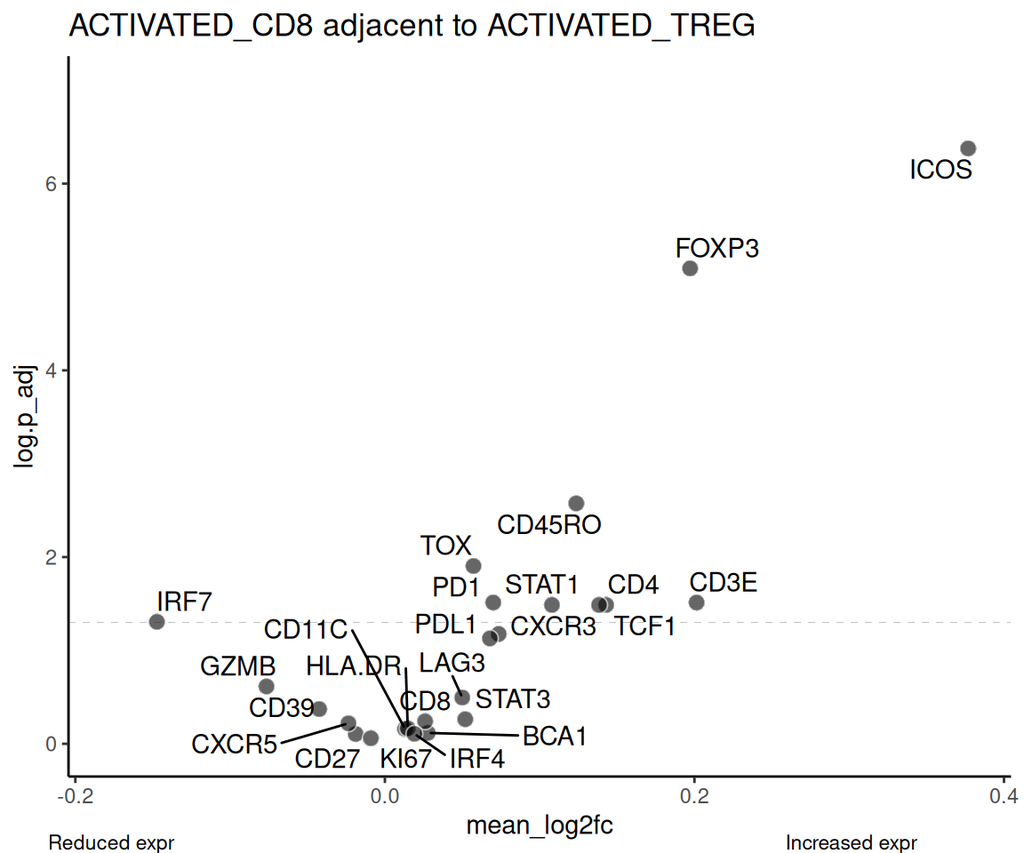

| feats | mean_sel | mean_other | mean_log2fc | p_value | Welch_t | p_adj | log.p_adj | highlight.feat | 50% |
| --- | --- | --- | --- | --- | --- | --- | --- | --- | --- |
| IRF7 | 5.929317 | 6.173122 | -0.147283477 | 1.900300e-02 | -2.6507036 | 4.940781e-02 | 1.3062044 | 0 | 4.521 |
| GZMB | 3.522642 | 3.718000 | -0.076502196 | 1.402708e-01 | -1.5634193 | 2.431361e-01 | 0.6141506 | 0 | 3.515 |
| CD39 | 8.034043 | 8.324201 | -0.042431526 | 2.778960e-01 | -1.1289429 | 4.250174e-01 | 0.3715933 | 0 | 6.846 |
| CXCR5 | 6.634842 | 6.652703 | -0.023558671 | 4.646099e-01 | -0.7518234 | 6.039929e-01 | 0.2189682 | 0 | 5.767 |
| CD27 | 17.619200 | 17.002699 | -0.018862854 | 7.552122e-01 | -0.3179550 | 7.854207e-01 | 0.1048977 | 0 | 10.937 |
| KI67 | 4.800415 | 4.786171 | -0.009094553 | 8.719613e-01 | -0.1641475 | 8.719613e-01 | 0.0595028 | 0 | 4.103 |
| CD11C | 3.647406 | 3.654430 | 0.012993467 | 5.862260e-01 | 0.5571450 | 6.928125e-01 | 0.1593843 | 0 | 2.400 |
| HLA.DR | 21.166534 | 21.120278 | 0.014765996 | 5.519398e-01 | 0.6095269 | 6.833540e-01 | 0.1653542 | 0 | 4.634 |
| IRF4 | 9.522398 | 9.493467 | 0.019031842 | 7.220515e-01 | 0.3629664 | 7.822224e-01 | 0.1066697 | 0 | 8.657 |
| CD8 | 20.386092 | 20.126853 | 0.025987177 | 4.194277e-01 | 0.8319031 | 5.739537e-01 | 0.2411231 | 0 | 5.485 |

[output cut: 14 more lines]

```r
plot.volcano.icf(dt = icf.persample, receiver_cell = "ACTIVATED_CD8", sender_cell = "ACTIVATED_TREG", threshold.values = thresholds)
```

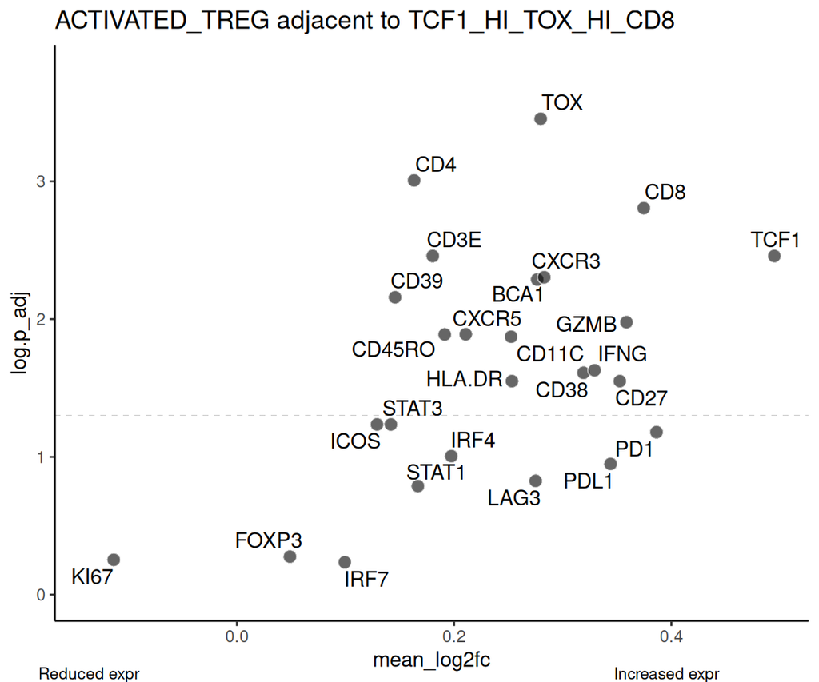

| feats | mean_sel | mean_other | mean_log2fc | p_value | Welch_t | p_adj | log.p_adj | highlight.feat | 50% |
| --- | --- | --- | --- | --- | --- | --- | --- | --- | --- |
| KI67 | 7.827962 | 7.634122 | -0.11336548 | 5.375151e-01 | -0.6320887 | 0.5590157557 | 0.2525760 | 0 | 4.103 |
| FOXP3 | 8.701087 | 8.368753 | 0.04883623 | 4.889468e-01 | 0.7106913 | 0.5296924192 | 0.2759762 | 0 | 1.631 |
| IRF7 | 7.326667 | 6.627133 | 0.09934039 | 5.816920e-01 | 0.5639776 | 0.5816920475 | 0.2353069 | 0 | 4.521 |
| ICOS | 7.265273 | 6.745400 | 0.12900499 | 3.983081e-02 | 2.2660255 | 0.0581071900 | 1.2357701 | 0 | 1.502 |
| STAT3 | 16.460854 | 14.846540 | 0.14174022 | 4.022805e-02 | 2.2607704 | 0.0581071900 | 1.2357701 | 0 | 11.768 |
| CD39 | 9.521133 | 8.631724 | 0.14559869 | 2.137310e-03 | 3.7537901 | 0.0069462578 | 2.1582491 | 0 | 6.846 |
| CD4 | 17.194462 | 15.597688 | 0.16318913 | 7.580429e-05 | 5.5176255 | 0.0009854558 | 3.0063629 | 0 | 5.852 |
| STAT1 | 21.956732 | 19.574981 | 0.16665794 | 1.439643e-01 | 1.5478389 | 0.1627422925 | 0.7884996 | 0 | 12.035 |
| CD3E | 23.167402 | 21.000975 | 0.18037860 | 5.496343e-04 | 4.4497759 | 0.0034835254 | 2.4579810 | 0 | 7.591 |
| CD45RO | 19.379041 | 16.496760 | 0.19136748 | 5.467887e-03 | 3.2807373 | 0.0129240962 | 1.8885998 | 0 | 8.403 |

[output cut: 16 more lines]

```r
plot.volcano.icf(dt = icf.persample, receiver_cell = "ACTIVATED_TREG", sender_cell = "TCF1_HI_TOX_HI_CD8", threshold.values = thresholds)
```

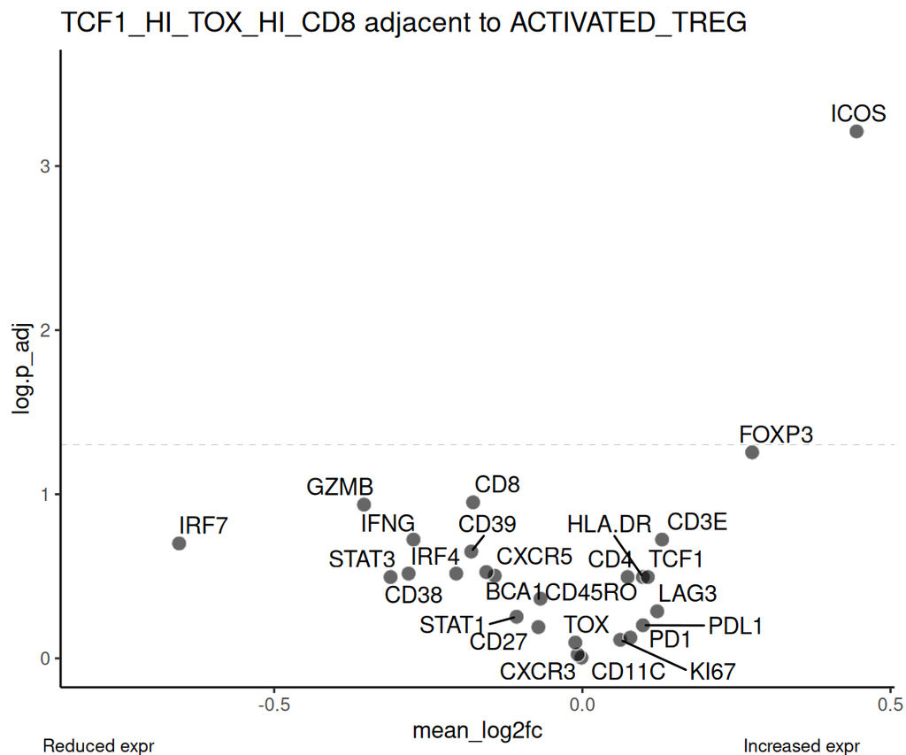

| feats | mean_sel | mean_other | mean_log2fc | p_value | Welch_t | p_adj | log.p_adj | highlight.feat | 50% |
| --- | --- | --- | --- | --- | --- | --- | --- | --- | --- |
| IRF7 | 7.911506 | 8.778430 | -0.654265750 | 5.369976e-02 | -2.10633542 | 0.1994562412 | 0.700152370 | 0 | 4.521 |
| GZMB | 6.944472 | 8.538168 | -0.354312893 | 1.780463e-02 | -2.68402940 | 0.1157301015 | 0.936553666 | 0 | 3.515 |
| STAT3 | 17.060701 | 18.281343 | -0.311220014 | 1.729154e-01 | -1.43619272 | 0.3197048578 | 0.495250765 | 0 | 11.768 |
| IRF4 | 12.249650 | 13.228245 | -0.281965063 | 1.287665e-01 | -1.61430550 | 0.3043572029 | 0.516616416 | 0 | 8.657 |
| IFNG | 6.551450 | 7.486741 | -0.274065464 | 4.125168e-02 | -2.24745089 | 0.1888796092 | 0.723814925 | 0 | 3.800 |
| CD38 | 10.343823 | 11.281739 | -0.204712598 | 1.236662e-01 | -1.63812732 | 0.3043572029 | 0.516616416 | 0 | 6.413 |
| CD39 | 10.710737 | 12.291311 | -0.180314507 | 6.877306e-02 | -1.97140786 | 0.2235124314 | 0.650698317 | 0 | 6.846 |
| CD8 | 20.957515 | 23.659941 | -0.177332242 | 1.293164e-02 | -2.84678577 | 0.1120742547 | 0.950494140 | 0 | 5.485 |
| CXCR5 | 9.129445 | 10.087594 | -0.155859296 | 1.031945e-01 | -1.74327622 | 0.2981173727 | 0.525612715 | 0 | 5.767 |
| BCA1 | 6.996901 | 7.752127 | -0.142172930 | 1.447918e-01 | -1.54439494 | 0.3137156702 | 0.503463788 | 0 | 3.720 |

[output cut: 16 more lines]

```r
plot.volcano.icf(dt = icf.persample, receiver_cell = "TCF1_HI_TOX_HI_CD8", sender_cell = "ACTIVATED_TREG", threshold.values = thresholds)
```

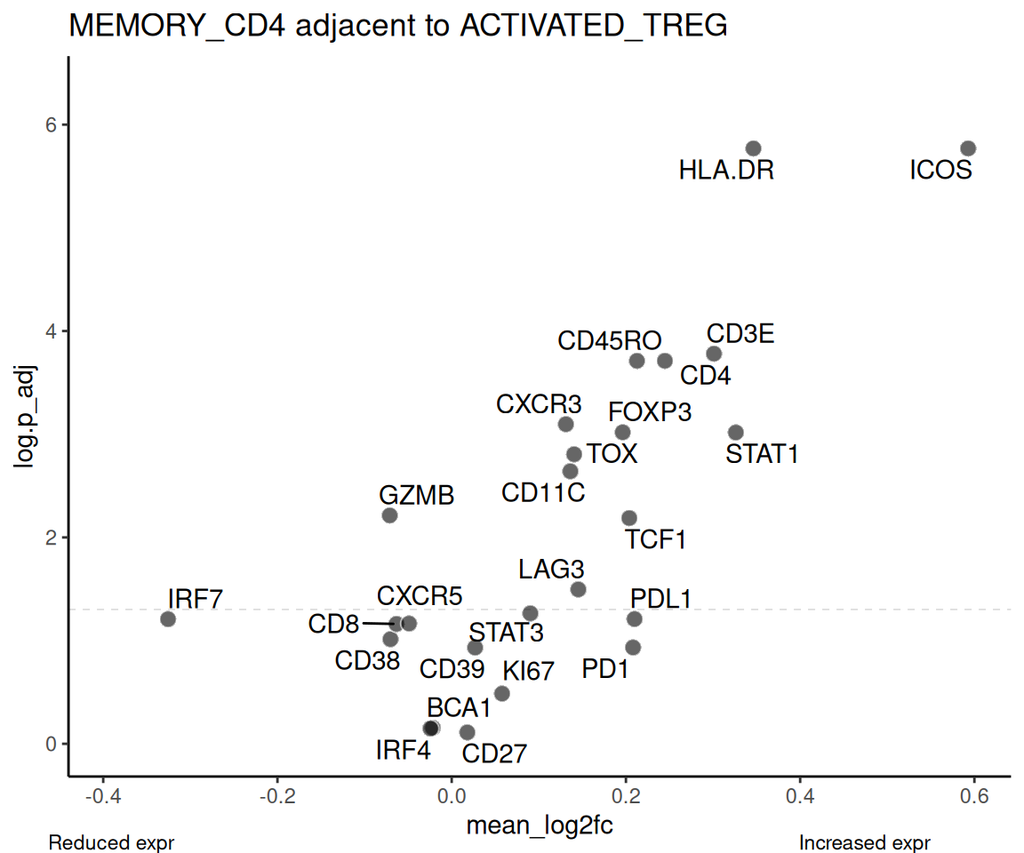

| feats | mean_sel | mean_other | mean_log2fc | p_value | Welch_t | p_adj | log.p_adj | highlight.feat | 50% |
| --- | --- | --- | --- | --- | --- | --- | --- | --- | --- |
| IRF7 | 6.278361 | 6.761280 | -0.32556424 | 4.050370e-02 | -2.2571526 | 6.194684e-02 | 1.2079809 | 0 | 4.521 |
| GZMB | 3.745760 | 3.901374 | -0.07106657 | 2.592882e-03 | -3.6561841 | 6.128629e-03 | 2.2126367 | 0 | 3.515 |
| CD38 | 6.513228 | 6.869011 | -0.07025954 | 7.456308e-02 | -1.9267003 | 9.693200e-02 | 1.0135328 | 0 | 6.413 |
| CD8 | 5.951199 | 6.226587 | -0.06336665 | 5.042020e-02 | -2.1402891 | 6.899606e-02 | 1.1611757 | 0 | 5.485 |
| CXCR5 | 7.234228 | 7.362083 | -0.04894702 | 4.731620e-02 | -2.1743705 | 6.834562e-02 | 1.1652893 | 0 | 5.767 |
| IRF4 | 9.719892 | 10.021048 | -0.02434762 | 6.845686e-01 | -0.4148084 | 7.119513e-01 | 0.1475497 | 0 | 8.657 |
| BCA1 | 5.292575 | 5.053081 | -0.02177753 | 6.456624e-01 | -0.4698995 | 6.994676e-01 | 0.1552324 | 0 | 3.720 |
| CD27 | 18.556832 | 17.769674 | 0.01793205 | 7.756948e-01 | 0.2904969 | 7.756948e-01 | 0.1103091 | 0 | 10.937 |
| CD39 | 7.033588 | 6.915280 | 0.02689223 | 9.892526e-02 | 1.7674919 | 1.169117e-01 | 0.9321421 | 0 | 6.846 |
| KI67 | 5.443835 | 5.254728 | 0.05785356 | 2.888382e-01 | 1.1024965 | 3.265127e-01 | 0.4860999 | 0 | 4.103 |

[output cut: 15 more lines]

```r
plot.volcano.icf(dt = icf.persample, receiver_cell = "MEMORY_CD4", sender_cell = "ACTIVATED_TREG", threshold.values = thresholds)
```

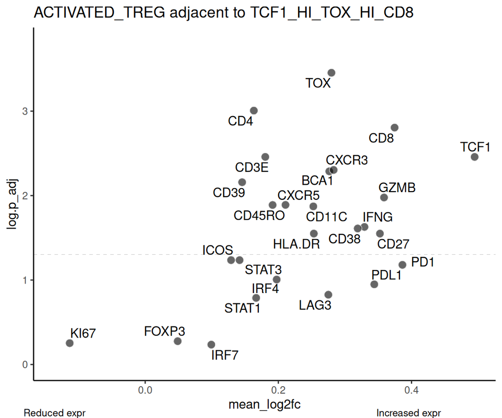

| feats | mean_sel | mean_other | mean_log2fc | p_value | Welch_t | p_adj | log.p_adj | highlight.feat |
| --- | --- | --- | --- | --- | --- | --- | --- | --- |
| KI67 | 7.827962 | 7.634122 | -0.11336548 | 5.375151e-01 | -0.6320887 | 0.5590157557 | 0.2525760 | 0 |
| FOXP3 | 8.701087 | 8.368753 | 0.04883623 | 4.889468e-01 | 0.7106913 | 0.5296924192 | 0.2759762 | 0 |
| IRF7 | 7.326667 | 6.627133 | 0.09934039 | 5.816920e-01 | 0.5639776 | 0.5816920475 | 0.2353069 | 0 |
| ICOS | 7.265273 | 6.745400 | 0.12900499 | 3.983081e-02 | 2.2660255 | 0.0581071900 | 1.2357701 | 0 |
| STAT3 | 16.460854 | 14.846540 | 0.14174022 | 4.022805e-02 | 2.2607704 | 0.0581071900 | 1.2357701 | 0 |
| CD39 | 9.521133 | 8.631724 | 0.14559869 | 2.137310e-03 | 3.7537901 | 0.0069462578 | 2.1582491 | 0 |
| CD4 | 17.194462 | 15.597688 | 0.16318913 | 7.580429e-05 | 5.5176255 | 0.0009854558 | 3.0063629 | 0 |
| STAT1 | 21.956732 | 19.574981 | 0.16665794 | 1.439643e-01 | 1.5478389 | 0.1627422925 | 0.7884996 | 0 |
| CD3E | 23.167402 | 21.000975 | 0.18037860 | 5.496343e-04 | 4.4497759 | 0.0034835254 | 2.4579810 | 0 |
| CD45RO | 19.379041 | 16.496760 | 0.19136748 | 5.467887e-03 | 3.2807373 | 0.0129240962 | 1.8885998 | 0 |

[output cut: 16 more lines]

```r
plot.volcano.icf(dt = icf.persample, receiver_cell = "ACTIVATED_TREG", sender_cell = "TCF1_HI_TOX_HI_CD8")
```

```r
# plot.volcano.icf(dt = icf.persample.thresh, receiver_cell = "ACTIVATED_TREG", sender_cell = "TCF1_HI_TOX_HI_CD8")
```

This is curious. It’s maybe also showing membrane spillover from the adjacent cell. All of the recipient cells have ICOS and Foxp3 which is likely coming from the ACTIVATED_TREG.

# 5 heatmap of the ICF

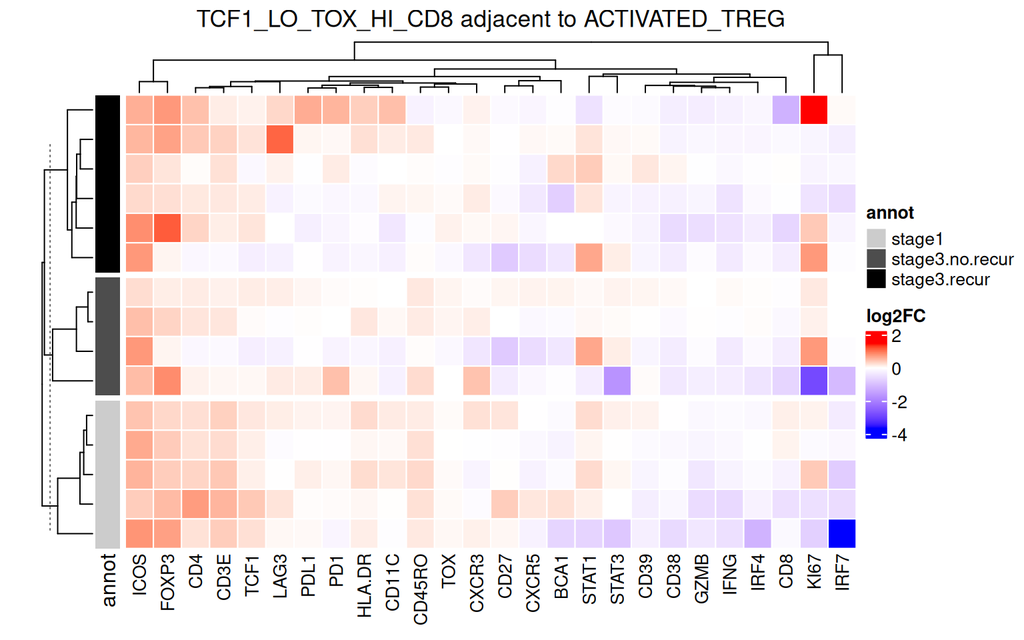

```r
index.cell = "TCF1_LO_TOX_HI_CD8"
interacting.cell = "ACTIVATED_TREG"
df.for.plot <- icf.persample[int_cell_type == interacting.cell & cell_type == index.cell]
annotation.df <- data.frame(list_ID = c(stage1.subgroup, recur.subgroup, norecur.subgroup))
annotation.df$annot <- c(rep("stage1", 5), rep("stage3.recur", length(recur.subgroup)),
                         rep("stage3.no.recur", length(norecur.subgroup)))
rownames(annotation.df) <- annotation.df$list_ID
annotation.df$list_ID <- NULL
heatmap.feats <- proteinsList # c("IFNG", "GZMB", "HLADR")
heatmap.matrix <- df.for.plot[feats %in% heatmap.feats, .(log2fc, feats, list_ID)]
heatmap.matrix <- (heatmap.matrix %>% pivot_wider(names_from = feats, values_from=log2fc, id_cols = list_ID)) %>%
   tibble::column_to_rownames("list_ID")
heatmap.matrix <- heatmap.matrix[rownames(annotation.df), ] %>% as.matrix()
colors <- c("stage1" = "gray80", "stage3.no.recur" = "gray30", "stage3.recur" = "black")
ht.annot <- HeatmapAnnotation(df = annotation.df, col = list(annot = colors), which = "row")
col.fxn <- circlize::colorRamp2(c(min(as.vector(heatmap.matrix)), 0, max(as.vector(heatmap.matrix))), c("blue", "white", "red"))

Heatmap(  heatmap.matrix, name = "log2FC",
  row_split = annotation.df$annot, left_annotation = ht.annot, rect_gp = gpar(col = "white", lwd = 1),
  cluster_rows = TRUE, cluster_columns = TRUE, show_row_names = F, col = col.fxn,
  row_names_gp = gpar(fontsize = 10),  column_names_gp = gpar(fontsize = 10),
  column_title = (paste0(index.cell, " adjacent to ", interacting.cell)), row_title = " "
)
```

# 6 regroup Treg subgroups into one entity in L2_annotations

```r
md.mod <- md
md.mod[, L2_annotations.mergeTreg:= L2_annotations]
md.mod[L2_annotations.mergeTreg %like% "TREG", L2_annotations.mergeTreg := "TREG"]
newdf <- data.frame(cell_ID=md.mod$cell_ID, L2_annotations.mergeTreg = md.mod$L2_annotations.mergeTreg)
sln <- addCellMetadata(gobject = sln, new_metadata = newdf, by_column=T, column_cell_ID = 'cell_ID')
md <- pDataDT(sln)
icf.persample.regroup <- list()
for (i in list_ID)
{
  if( .Platform$OS.type != "windows")    {    cat(paste("Starting on: ", i, " on ", date(),"\n"),
                                                  file = paste0("progress.",timeStamp,".txt"), append = T)   }
  keepCells <- subset(md, list_ID %in% i )
  sln.sm <- subsetGiotto(gobject = sln, cell_ids = keepCells$cell_ID)
  sln.sm <- createSpatialKNNnetwork(sln.sm, k=9, verbose=T, name = "spatialknn.k9.persample")
  print("made spatialKNN")
  print(getSpatialNetwork(sln.sm))
  res <- findInteractionChangedFeats(gobject = sln.sm, selected_feats = proteinsList,
                                     spatial_network_name = "spatialknn.k9.persample",
                                     cluster_column = "L2_annotations.mergeTreg", diff_test = 'permutation',
                                     adjust_method = 'fdr', nr_permutations = 1, do_parallel = T)
  res$list_ID <- i
  icf.persample.regroup[i] <- res
  print(paste("Random downsample process for", i, "ends at", date()))
}
```

```
## Setting spatial network [cell] spatialknn.k9.persample
```

```
## [1] "made spatialKNN"
## An object of class spatialNetworkObj : "spatialknn.k5"
## Contains spatial network generated with: dbscan
## spat_unit : "cell"
## provenance: cell
##    1404496 connections (filtered)
```

```
## [1] "Random downsample process for ctrl.1 ends at Fri Oct 31 18:57:13 2025"
```

```
## Setting spatial network [cell] spatialknn.k9.persample
```

```
## [1] "made spatialKNN"
## An object of class spatialNetworkObj : "spatialknn.k5"
## Contains spatial network generated with: dbscan
## spat_unit : "cell"
## provenance: cell
##    310233 connections (filtered)
```

```
## [1] "Random downsample process for tumor.4 ends at Fri Oct 31 18:59:29 2025"
```

```
## Setting spatial network [cell] spatialknn.k9.persample
```

```
## [1] "made spatialKNN"
## An object of class spatialNetworkObj : "spatialknn.k5"
## Contains spatial network generated with: dbscan
## spat_unit : "cell"
## provenance: cell
##    746026 connections (filtered)
```

```
## [1] "Random downsample process for tumor.5 ends at Fri Oct 31 19:03:34 2025"
```

```
## Setting spatial network [cell] spatialknn.k9.persample
```

```
## [1] "made spatialKNN"
## An object of class spatialNetworkObj : "spatialknn.k5"
## Contains spatial network generated with: dbscan
## spat_unit : "cell"
## provenance: cell
##    2062659 connections (filtered)
```

```
## [1] "Random downsample process for ctrl.2 ends at Fri Oct 31 19:10:25 2025"
```

```
## Setting spatial network [cell] spatialknn.k9.persample
```

```
## [1] "made spatialKNN"
## An object of class spatialNetworkObj : "spatialknn.k5"
## Contains spatial network generated with: dbscan
## spat_unit : "cell"
## provenance: cell
##    1888081 connections (filtered)
```

```
## [1] "Random downsample process for tumor.7 ends at Fri Oct 31 19:16:57 2025"
```

```
## Setting spatial network [cell] spatialknn.k9.persample
```

```
## [1] "made spatialKNN"
## An object of class spatialNetworkObj : "spatialknn.k5"
## Contains spatial network generated with: dbscan
## spat_unit : "cell"
## provenance: cell
##    5487423 connections (filtered)
```

```
## [1] "Random downsample process for tumor.6 ends at Fri Oct 31 19:28:25 2025"
```

```
## Setting spatial network [cell] spatialknn.k9.persample
```

```
## [1] "made spatialKNN"
## An object of class spatialNetworkObj : "spatialknn.k5"
## Contains spatial network generated with: dbscan
## spat_unit : "cell"
## provenance: cell
##    2865975 connections (filtered)
```

```
## [1] "Random downsample process for tumor.8 ends at Fri Oct 31 19:36:13 2025"
```

```
## Setting spatial network [cell] spatialknn.k9.persample
```

```
## [1] "made spatialKNN"
## An object of class spatialNetworkObj : "spatialknn.k5"
## Contains spatial network generated with: dbscan
## spat_unit : "cell"
## provenance: cell
##    2570758 connections (filtered)
```

```
## [1] "Random downsample process for ctrl.3 ends at Fri Oct 31 19:43:45 2025"
```

```
## Setting spatial network [cell] spatialknn.k9.persample
```

```
## [1] "made spatialKNN"
## An object of class spatialNetworkObj : "spatialknn.k5"
## Contains spatial network generated with: dbscan
## spat_unit : "cell"
## provenance: cell
##    2593986 connections (filtered)
```

```
## [1] "Random downsample process for tumor.9 ends at Fri Oct 31 19:51:25 2025"
```

```
## Setting spatial network [cell] spatialknn.k9.persample
```

```
## [1] "made spatialKNN"
## An object of class spatialNetworkObj : "spatialknn.k5"
## Contains spatial network generated with: dbscan
## spat_unit : "cell"
## provenance: cell
##    2601274 connections (filtered)
```

```
## [1] "Random downsample process for tumor.10 ends at Fri Oct 31 19:58:42 2025"
```

```
## Setting spatial network [cell] spatialknn.k9.persample
```

```
## [1] "made spatialKNN"
## An object of class spatialNetworkObj : "spatialknn.k5"
## Contains spatial network generated with: dbscan
## spat_unit : "cell"
## provenance: cell
##    1766731 connections (filtered)
```

```
## [1] "Random downsample process for ctrl.4 ends at Fri Oct 31 20:05:12 2025"
```

```
## Setting spatial network [cell] spatialknn.k9.persample
```

```
## [1] "made spatialKNN"
## An object of class spatialNetworkObj : "spatialknn.k5"
## Contains spatial network generated with: dbscan
## spat_unit : "cell"
## provenance: cell
##    1466196 connections (filtered)
```

```
## [1] "Random downsample process for ctrl.5 ends at Fri Oct 31 20:10:27 2025"
```

```
## Setting spatial network [cell] spatialknn.k9.persample
```

```
## [1] "made spatialKNN"
## An object of class spatialNetworkObj : "spatialknn.k5"
## Contains spatial network generated with: dbscan
## spat_unit : "cell"
## provenance: cell
##    534714 connections (filtered)
```

```
## [1] "Random downsample process for tumor.1 ends at Fri Oct 31 20:13:19 2025"
```

```
## Setting spatial network [cell] spatialknn.k9.persample
```

```
## [1] "made spatialKNN"
## An object of class spatialNetworkObj : "spatialknn.k5"
## Contains spatial network generated with: dbscan
## spat_unit : "cell"
## provenance: cell
##    2950573 connections (filtered)
```

```
## [1] "Random downsample process for tumor.2 ends at Fri Oct 31 20:21:13 2025"
```

```
## Setting spatial network [cell] spatialknn.k9.persample
```

```
## [1] "made spatialKNN"
## An object of class spatialNetworkObj : "spatialknn.k5"
## Contains spatial network generated with: dbscan
## spat_unit : "cell"
## provenance: cell
##    3001695 connections (filtered)
```

```
## [1] "Random downsample process for tumor.3 ends at Fri Oct 31 20:29:29 2025"
```

```r
saveRDS(icf.persample.regroup, file = "neighborhood.ICFlistmod.perSample.sln.clustering5.spatnet.RDS")
icf.persample.regroup <- purrr::list_rbind(icf.persample.regroup, names_to = "list_ID")
```

```r
icf.persample.regroup <- purrr::list_rbind(readRDS(file="neighborhood.ICFlistmod.perSample.sln.clustering5.spatnet.RDS"),
                                    names_to = "list_ID")
```

# 7 regroup the Treg

What if we instead think about all the Treg together? Would that give us more Treg that aren’t already in the terminal phenotype? It might recover more cells that were possibly misclassified. Maybe it would show phenotypic change in the Treg that are near CD8, sort of like an orthogonal way to recreate the cellProximityEnrichment analysis

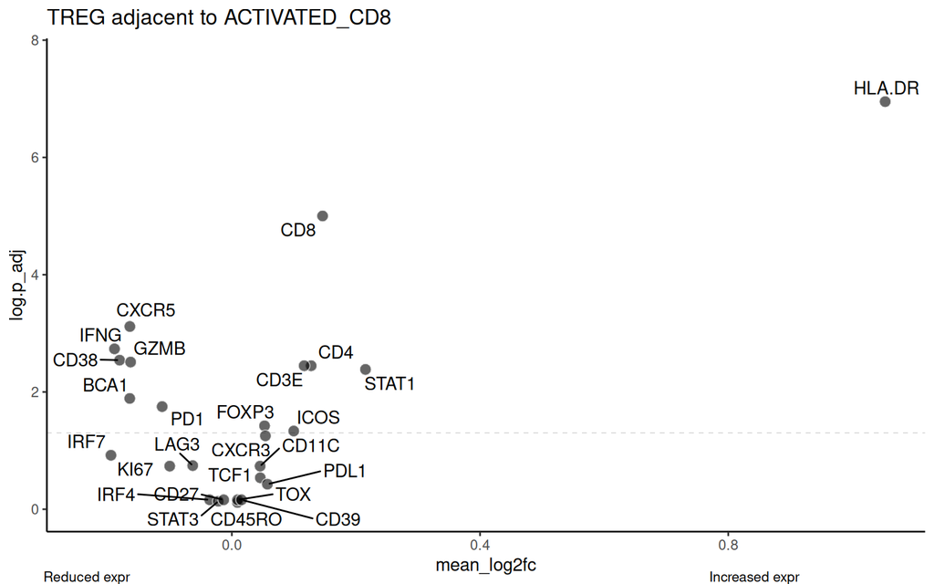

| feats | mean_sel | mean_other | mean_log2fc | p_value | Welch_t | p_adj | log.p_adj | highlight.feat |
| --- | --- | --- | --- | --- | --- | --- | --- | --- |
| IRF7 | 6.139451 | 6.821949 | -0.194793341 | 6.933849e-02 | -1.9668941 | 1.201867e-01 | 0.9201435 | 0 |
| IFNG | 3.757693 | 4.283267 | -0.189083018 | 2.830376e-04 | -4.7991102 | 1.839744e-03 | 2.7352426 | 0 |
| CD38 | 6.498589 | 7.372830 | -0.180849862 | 5.516736e-04 | -4.4478466 | 2.868703e-03 | 2.5423145 | 0 |
| BCA1 | 5.284436 | 5.504822 | -0.164519807 | 4.959818e-03 | -3.3297511 | 1.289553e-02 | 1.8895609 | 0 |
| CXCR5 | 7.015607 | 7.826126 | -0.164320742 | 8.826604e-05 | -5.4326747 | 7.649723e-04 | 3.1163543 | 0 |
| GZMB | 3.577940 | 4.023924 | -0.163157254 | 7.127475e-04 | -4.3148713 | 3.088573e-03 | 2.5102422 | 0 |
| PD1 | 1.614656 | 1.716806 | -0.112296138 | 7.518442e-03 | -3.1205925 | 1.777086e-02 | 1.7502915 | 0 |
| KI67 | 5.631620 | 6.185109 | -0.100089236 | 1.274562e-01 | -1.6203466 | 1.841034e-01 | 0.7349381 | 0 |
| LAG3 | 2.621759 | 2.670706 | -0.063048471 | 1.108630e-01 | -1.7019135 | 1.801524e-01 | 0.7443599 | 0 |
| IRF4 | 9.680016 | 10.039424 | -0.035723832 | 6.357239e-01 | -0.4842101 | 6.911203e-01 | 0.1604464 | 0 |

[output cut: 16 more lines]

```r
plot.volcano.icf(dt = icf.persample.regroup, receiver_cell = "TREG", sender_cell = "ACTIVATED_CD8")
```

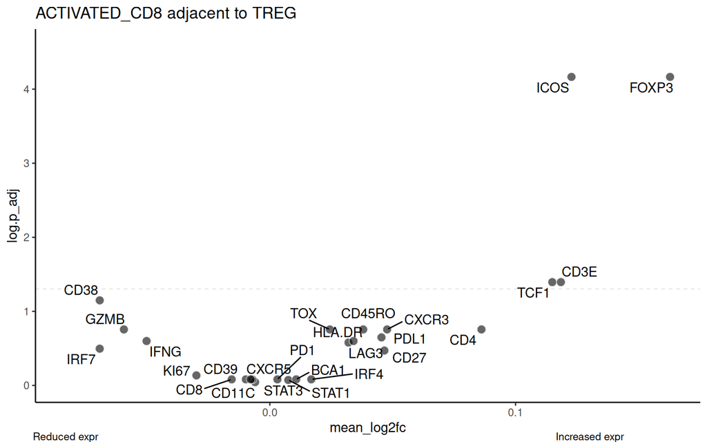

| feats | mean_sel | mean_other | mean_log2fc | p_value | Welch_t | p_adj | log.p_adj | highlight.feat |
| --- | --- | --- | --- | --- | --- | --- | --- | --- |
| IRF7 | 5.974149 | 6.201882 | -0.069236087 | 1.840978e-01 | -1.3972263 | 3.191028e-01 | 0.49606941 | 0 |
| CD38 | 6.222988 | 6.604990 | -0.069229757 | 1.365344e-02 | -2.8192296 | 7.099788e-02 | 1.14875465 | 0 |
| GZMB | 3.562172 | 3.736918 | -0.059390035 | 5.123427e-02 | -2.1316739 | 1.755142e-01 | 0.75568781 | 0 |
| IFNG | 3.630665 | 3.747992 | -0.050168216 | 1.258386e-01 | -1.6278787 | 2.516773e-01 | 0.59915597 | 0 |
| KI67 | 4.652719 | 4.795682 | -0.029882781 | 4.789522e-01 | -0.7274293 | 7.325152e-01 | 0.13518337 | 0 |
| CD8 | 19.931623 | 20.197291 | -0.015519091 | 6.010423e-01 | -0.5350036 | 8.286948e-01 | 0.08160541 | 0 |
| CD39 | 8.255978 | 8.296725 | -0.009770441 | 6.644145e-01 | -0.4431693 | 8.286948e-01 | 0.08160541 | 0 |
| CD11C | 3.612338 | 3.660044 | -0.007787519 | 6.710048e-01 | -0.4338551 | 8.286948e-01 | 0.08160541 | 0 |
| CXCR5 | 6.614679 | 6.654309 | -0.007138049 | 7.649490e-01 | -0.3048718 | 8.286948e-01 | 0.08160541 | 0 |
| STAT3 | 13.657804 | 13.621463 | -0.005990728 | 9.043819e-01 | -0.1223229 | 9.043819e-01 | 0.04364815 | 0 |

[output cut: 16 more lines]

```r
plot.volcano.icf(dt = icf.persample.regroup, receiver_cell = "ACTIVATED_CD8", sender_cell = "TREG")
```

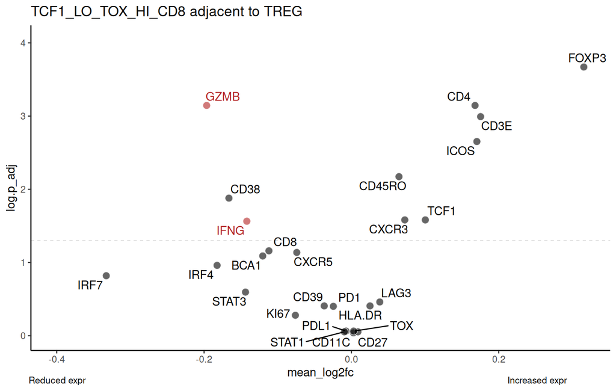

| feats | mean_sel | mean_other | mean_log2fc | p_value | Welch_t | p_adj | log.p_adj | highlight.feat |
| --- | --- | --- | --- | --- | --- | --- | --- | --- |
| IRF7 | 6.867369 | 7.358955 | -0.332775317 | 8.751706e-02 | -1.8370713 | 0.1516962296 | 0.81902521 | 0 |
| GZMB | 5.884795 | 6.773752 | -0.196480730 | 8.017347e-05 | -5.4862843 | 0.0007158871 | 3.14515547 | 1 |
| IRF4 | 9.745426 | 11.006935 | -0.182330722 | 5.897131e-02 | -2.0555826 | 0.1095181463 | 0.96051392 | 0 |
| CD38 | 7.903993 | 9.089352 | -0.166284685 | 3.555473e-03 | -3.4971239 | 0.0132060417 | 1.87922733 | 0 |
| STAT3 | 14.310336 | 15.130043 | -0.143777740 | 1.561216e-01 | -1.4988450 | 0.2536975523 | 0.59568372 | 0 |
| IFNG | 4.560877 | 5.089238 | -0.141995622 | 1.050254e-02 | -2.9520808 | 0.0273066162 | 1.56373211 | 1 |
| BCA1 | 6.093586 | 6.389749 | -0.120371296 | 4.070847e-02 | -2.2544800 | 0.0814169486 | 1.08928518 | 0 |
| CD8 | 21.860251 | 24.005173 | -0.111990091 | 2.930761e-02 | -2.4270659 | 0.0692725268 | 1.15943897 | 0 |
| KI67 | 5.940859 | 6.203203 | -0.076045112 | 4.248663e-01 | -0.8219805 | 0.5260249290 | 0.27899367 | 0 |
| CXCR5 | 8.030874 | 8.396228 | -0.074145704 | 3.367032e-02 | -2.3545465 | 0.0729523600 | 1.13696065 | 0 |

[output cut: 16 more lines]

```r
plot.volcano.icf(dt = icf.persample.regroup, receiver_cell = "TCF1_LO_TOX_HI_CD8", sender_cell = "TREG", key.feat = c("GZMB", "IFNG"))
```

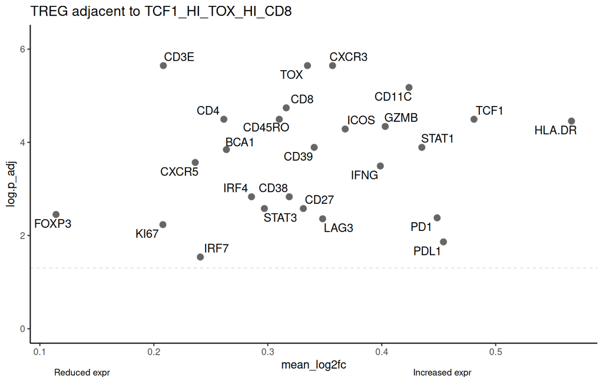

| feats | mean_sel | mean_other | mean_log2fc | p_value | Welch_t | p_adj | log.p_adj | highlight.feat |
| --- | --- | --- | --- | --- | --- | --- | --- | --- |
| FOXP3 | 7.834285 | 7.258176 | 0.1141680 | 2.856159e-03 | 3.607414 | 3.536197e-03 | 2.451464 | 0 |
| KI67 | 6.483292 | 6.062134 | 0.2079402 | 5.383221e-03 | 3.288580 | 5.831822e-03 | 2.234196 | 0 |
| CD3E | 21.032243 | 18.025008 | 0.2083516 | 2.051329e-07 | 9.380153 | 2.257164e-06 | 5.646437 | 0 |
| CXCR5 | 8.736561 | 7.582267 | 0.2363337 | 1.561533e-04 | 5.118947 | 2.706658e-04 | 3.567567 | 0 |
| IRF7 | 7.327884 | 6.650754 | 0.2408094 | 2.891465e-02 | 2.434094 | 2.891465e-02 | 1.538882 | 0 |
| CD4 | 15.743267 | 13.316906 | 0.2614172 | 9.840892e-06 | 6.716344 | 3.198290e-05 | 4.495082 | 0 |
| BCA1 | 6.433489 | 5.422440 | 0.2636731 | 7.708420e-05 | 5.508253 | 1.431564e-04 | 3.844189 | 0 |
| IRF4 | 11.249368 | 9.872020 | 0.2856944 | 1.008887e-03 | 4.135916 | 1.473099e-03 | 2.831768 | 0 |
| STAT3 | 15.829923 | 13.766339 | 0.2969995 | 2.025014e-03 | 3.781098 | 2.632518e-03 | 2.579629 | 0 |
| CD45RO | 17.012572 | 13.501684 | 0.3100630 | 9.259043e-06 | 6.754009 | 3.198290e-05 | 4.495082 | 0 |

[output cut: 16 more lines]

```r
  # ggsave(filename = 'output/icf.tcflo-near-treg.volcano.pdf', height=4, width=5)
plot.volcano.icf(dt = icf.persample.regroup, receiver_cell = "TREG", sender_cell = "TCF1_HI_TOX_HI_CD8")
```

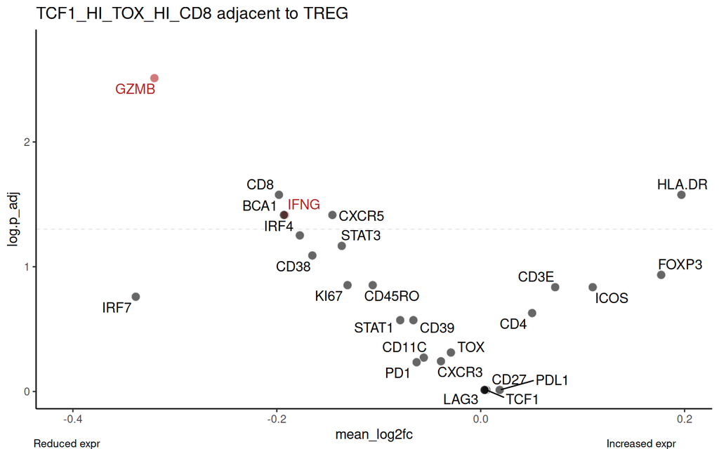

| feats | mean_sel | mean_other | mean_log2fc | p_value | Welch_t | p_adj | log.p_adj | highlight.feat |
| --- | --- | --- | --- | --- | --- | --- | --- | --- |
| IRF7 | 8.116294 | 9.029946 | -0.338336302 | 0.100369082 | -1.75920075 | 0.173973075 | 0.75951796 | 0 |
| GZMB | 7.137438 | 9.009697 | -0.320073068 | 0.000118424 | -5.27014150 | 0.003079023 | 2.51158708 | 1 |
| CD8 | 21.231197 | 24.206843 | -0.197892851 | 0.003060069 | -3.57266538 | 0.026520601 | 1.57641663 | 0 |
| BCA1 | 7.038171 | 7.963683 | -0.192996064 | 0.006986102 | -3.15754281 | 0.038462659 | 1.41496070 | 0 |
| IFNG | 6.834610 | 7.753293 | -0.191989777 | 0.007812812 | -3.10126009 | 0.038462659 | 1.41496070 | 1 |
| IRF4 | 12.110385 | 13.533751 | -0.177391242 | 0.015097038 | -2.76814894 | 0.056074713 | 1.25123294 | 0 |
| CD38 | 10.444016 | 11.467064 | -0.165159974 | 0.028121778 | -2.44855717 | 0.081240691 | 1.09022639 | 0 |
| CXCR5 | 9.412104 | 10.271849 | -0.145461080 | 0.008875998 | -3.03698926 | 0.038462659 | 1.41496070 | 0 |
| STAT3 | 17.015091 | 18.626581 | -0.136287394 | 0.020943196 | -2.60083682 | 0.068065387 | 1.16707368 | 0 |
| KI67 | 7.065388 | 7.616319 | -0.130614259 | 0.060492442 | -2.04171513 | 0.140476469 | 0.85239642 | 0 |

[output cut: 16 more lines]

```r
plot.volcano.icf(dt = icf.persample.regroup, receiver_cell = "TCF1_HI_TOX_HI_CD8", sender_cell = "TREG", key.feat = c("GZMB", "IFNG"))
```

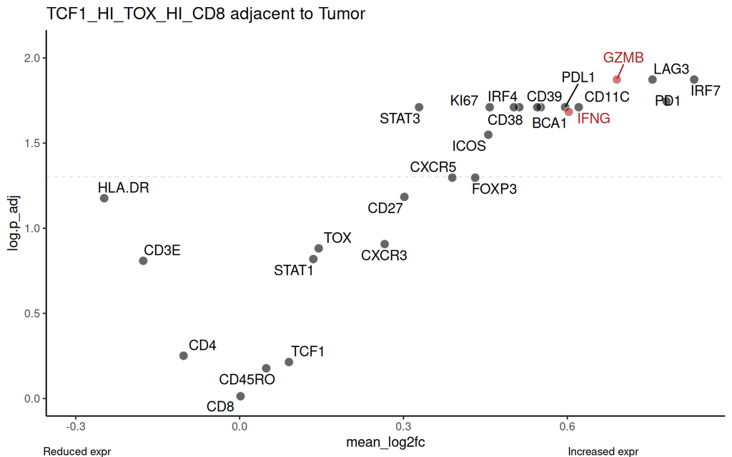

| feats | mean_sel | mean_other | mean_log2fc | p_value | Welch_t | p_adj | log.p_adj | highlight.feat |
| --- | --- | --- | --- | --- | --- | --- | --- | --- |
| HLA.DR | 11.340301 | 13.287574 | -0.247945746 | 0.046141987 | -2.1878086 | 0.06664954 | 1.17620286 | 0 |
| CD3E | 18.557424 | 21.567440 | -0.176453572 | 0.131495036 | -1.6018938 | 0.15540322 | 0.80853997 | 0 |
| CD4 | 13.155472 | 14.614345 | -0.102679492 | 0.496115114 | -0.6988124 | 0.56082578 | 0.25117203 | 0 |
| CD8 | 23.654198 | 23.564488 | 0.001727566 | 0.970324167 | 0.0378724 | 0.97032417 | 0.01308315 | 0 |
| CD45RO | 21.119237 | 20.790387 | 0.048710290 | 0.639180729 | 0.4792208 | 0.66474796 | 0.17734299 | 0 |
| TCF1 | 12.592731 | 12.079790 | 0.090344540 | 0.563707691 | 0.5913580 | 0.61068333 | 0.21418393 | 0 |
| STAT1 | 25.002270 | 23.390103 | 0.134949428 | 0.122535467 | 1.6435235 | 0.15171058 | 0.81898414 | 0 |
| TOX | 30.717132 | 28.343671 | 0.144783805 | 0.100996910 | 1.7556283 | 0.13129598 | 0.88174856 | 0 |
| CXCR3 | 12.237732 | 10.350090 | 0.265553300 | 0.090578290 | 1.8176420 | 0.12394924 | 0.90675614 | 0 |
| CD27 | 30.084662 | 24.766961 | 0.301638932 | 0.042807935 | 2.2277833 | 0.06547096 | 1.18395129 | 0 |

[output cut: 16 more lines]

```r
  # ggsave(filename = 'output/icf.tcfhi-near-treg.volcano.pdf', height=4, width=5)
plot.volcano.icf(dt = icf.persample.regroup, receiver_cell = "TCF1_HI_TOX_HI_CD8", sender_cell = "Tumor", key.feat = c("GZMB", "IFNG"))
```

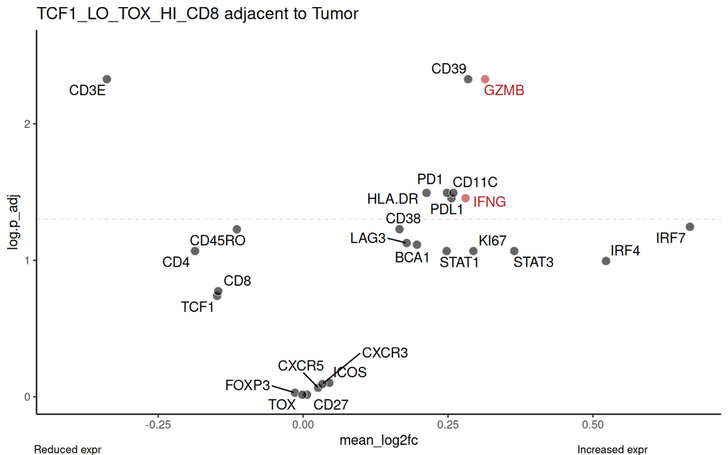

| feats | mean_sel | mean_other | mean_log2fc | p_value | Welch_t | p_adj | log.p_adj | highlight.feat |
| --- | --- | --- | --- | --- | --- | --- | --- | --- |
| CD3E | 13.925496 | 17.399256 | -0.338472451 | 0.0002660569 | -4.83206456 | 0.004710423 | 2.32694010 | 0 |
| CD4 | 8.711852 | 10.304375 | -0.186403030 | 0.0471135256 | -2.17666761 | 0.085589489 | 1.06757957 | 0 |
| TCF1 | 6.934008 | 7.652333 | -0.148363037 | 0.1403496096 | -1.56308328 | 0.182454492 | 0.73884544 | 0 |
| CD8 | 21.594049 | 23.742616 | -0.146496399 | 0.1231621434 | -1.64052751 | 0.168537670 | 0.77330301 | 0 |
| CD45RO | 16.048308 | 17.370309 | -0.114220633 | 0.0250906257 | -2.50769771 | 0.059305115 | 1.22690785 | 0 |
| FOXP3 | 3.480862 | 3.708622 | -0.014079177 | 0.8629982781 | -0.17576143 | 0.934914801 | 0.02922796 | 0 |
| TOX | 24.180036 | 24.546938 | -0.001255203 | 0.9666085704 | -0.04261716 | 0.966608570 | 0.01474936 | 0 |
| CD27 | 20.377440 | 20.713185 | 0.006720427 | 0.9525575891 | 0.06057031 | 0.966608570 | 0.01474936 | 0 |
| CXCR5 | 8.424734 | 8.376727 | 0.025875007 | 0.7594607754 | 0.31223925 | 0.858520877 | 0.06624914 | 0 |
| CXCR3 | 8.509881 | 8.384831 | 0.033281202 | 0.6824671408 | 0.41774867 | 0.806552075 | 0.09336759 | 0 |

[output cut: 16 more lines]

```r
  # ggsave(filename = 'output/icf.tcfhi-near-tumor.volcano.pdf', height=4, width=5)
plot.volcano.icf(dt = icf.persample.regroup, receiver_cell = "TCF1_LO_TOX_HI_CD8", sender_cell = "Tumor", key.feat = c("GZMB", "IFNG"))
```

```r
  # ggsave(filename = 'output/icf.tcflo-near-tumor.volcano.pdf', height=4, width=5)
```

Still seeing membrane spillover effects, that didn’t change. The CD8 adj to Treg again have lower GzmB and IFNg, esp in the Tcfhi CD8 subset.

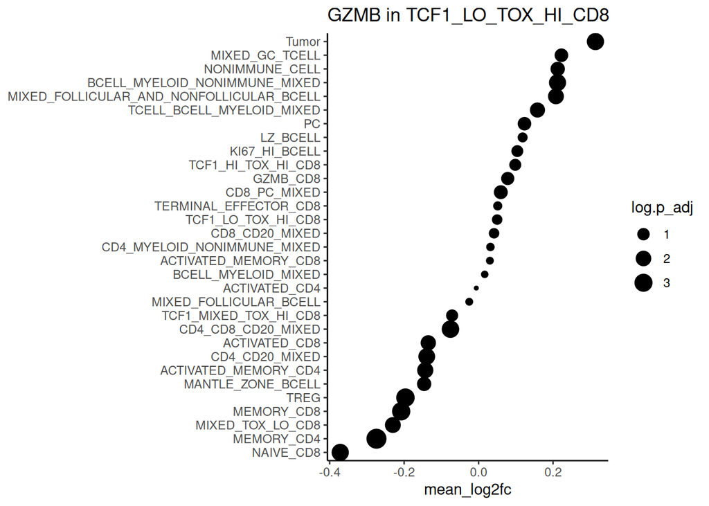

```r
# plot what is the effect of other sender celltypes on TCFlo for GzmB
probe.subset <- "TCF1_LO_TOX_HI_CD8";  probe.feature <- "GZMB"
dtable <- icf.persample.regroup[,.(list_ID, feats, log2fc, cell_type, int_cell_type, nr_select, int_nr_select)]  # simplify dtable
dtable <- dtable[cell_type == probe.subset, .(mean_log2fc = mean(log2fc, na.rm = TRUE),
                                           p_value = t.test(log2fc, mu = 0)$p.value,
                                           Welch_t = t.test(log2fc, mu = 0)$statistic ),
                                       by = .(feats, int_cell_type)  ] # calculate mean, pvalue, t stat
dtable <- dtable[! int_cell_type %in% c("ARTIFACT", "CD4.outlier","CD8.outlier")]
dtable[, p_adj := (p.adjust(p_value, method="fdr" )) ] # adjust p values using FDR method
dtable[, log.p_adj := -log10(p.adjust(p_value, method="fdr" )) ]
order <- dtable %>% arrange(mean_log2fc)
order <- order[feats == probe.feature, .(unique(int_cell_type))]
dtable$int_cell_type <- factor(dtable$int_cell_type, levels=order$V1)  # factor to make graph display in order
ggplot(dtable[feats == probe.feature], aes(y = int_cell_type, x=mean_log2fc, size=log.p_adj)) +
  geom_point(pch=21, color='black', fill='black',stroke=0.5) + theme_classic() +
  ggtitle(paste0(probe.feature, " in ", probe.subset)) +
  theme(axis.title.y = element_blank())
```

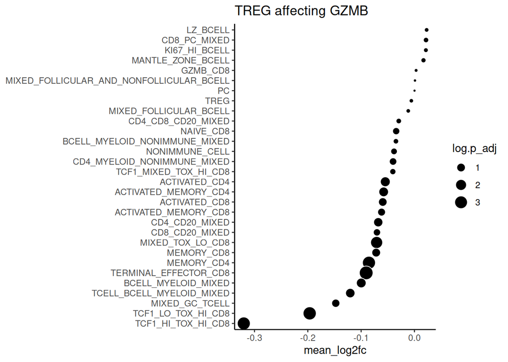

| feats | cell_type | mean_log2fc | p_value | Welch_t | p_adj | log.p_adj |
| --- | --- | --- | --- | --- | --- | --- |
| GZMB | CD4_CD20_MIXED | -0.0678906972 | 2.536328e-02 | -2.502105378 | 0.0576774343 | 1.238994067 |
| GZMB | PC | 0.0001808906 | 9.964060e-01 | 0.004585549 | 0.9964059749 | 0.001563677 |
| GZMB | MIXED_FOLLICULAR_AND_NONFOLLICULAR_BCELL | 0.0009968244 | 9.888621e-01 | 0.014211066 | 0.9914041870 | 0.003749251 |
| GZMB | CD8_PC_MIXED | 0.0217178925 | 5.414283e-01 | 0.625935370 | 0.6517192455 | 0.185939454 |
| GZMB | TCF1_HI_TOX_HI_CD8 | -0.3200730682 | 1.184240e-04 | -5.270141498 | 0.0007160518 | 3.145055538 |
| GZMB | MIXED_GC_TCELL | -0.1475503062 | 7.345454e-02 | -1.935009885 | 0.1354480935 | 0.868227104 |
| GZMB | CD4_CD8_CD20_MIXED | -0.0293751778 | 5.099509e-01 | -0.676167843 | 0.6224752297 | 0.205877926 |
| GZMB | BCELL_MYELOID_NONIMMUNE_MIXED | -0.0347018383 | 5.240655e-01 | -0.653431573 | 0.6370537670 | 0.195823912 |
| GZMB | CD4_MYELOID_NONIMMUNE_MIXED | -0.0400580976 | 1.453470e-01 | -1.542093718 | 0.2313687460 | 0.635695307 |
| GZMB | ACTIVATED_CD4 | -0.0546381343 | 1.250654e-02 | -2.863728972 | 0.0321950540 | 1.492210842 |

[output cut: 20 more lines]

```r
plot.icf.affectCells <- function( dt, probe.subset, probe.feature)
{
  dtable <- dt[,.(list_ID, feats, log2fc, cell_type, int_cell_type, nr_select, int_nr_select)] # simplify
  dtable <- dtable[int_cell_type == probe.subset, .(mean_log2fc = mean(log2fc, na.rm = TRUE),
                                             p_value = t.test(log2fc, mu = 0)$p.value,
                                             Welch_t = t.test(log2fc, mu = 0)$statistic ),
                                         by = .(feats, cell_type)  ]  # statistically summarize after subgrouping
  dtable <- dtable[! cell_type %in% c("ARTIFACT", "CD4.outlier","CD8.outlier","Tumor")]
  dtable[, p_adj := (p.adjust(p_value, method="fdr" )) ]
  dtable[, log.p_adj := -log10(p.adjust(p_value, method="fdr" )) ]
  order <- dtable %>% arrange(mean_log2fc)
  order <- order[feats == probe.feature, .(unique(cell_type))]
  dtable$cell_type <- factor(dtable$cell_type, levels=order$V1)  # this is a problem
  print(ggplot(dtable[feats == probe.feature], aes(y = cell_type, x=mean_log2fc, size=log.p_adj)) +
    geom_point(pch=21, color='white', fill='black',stroke=0.5) + theme_classic() +
    ggtitle(paste0(probe.subset, " affecting ", probe.feature)) +
    theme(axis.title.y = element_blank())
  )
  return(dtable[feats==probe.feature])

#      feats                                cell_type  mean_log2fc     p_value     Welch_t       p_adj  log.p_adj
#    <char>                                   <fctr>        <num>       <num>       <num>       <num>      <num>
# 1:   IFNG                           CD4_CD20_MIXED -0.061328114 0.066587619 -1.98917806 0.121424481 0.91569374
# 2:   IFNG                                       PC -0.028835847 0.582465746 -0.56280971 0.682806484 0.16570236
# 3:   IFNG MIXED_FOLLICULAR_AND_NONFOLLICULAR_BCELL  0.048100229 0.495967493  0.69905601 0.602503326 0.22004055
}

# now seeking to make the reverse, where you see what Treg's effects on GzmB are in receiver cells
plot.icf.affectCells(dt = icf.persample.regroup, probe.subset = "TREG",  probe.feature = "GZMB")
```

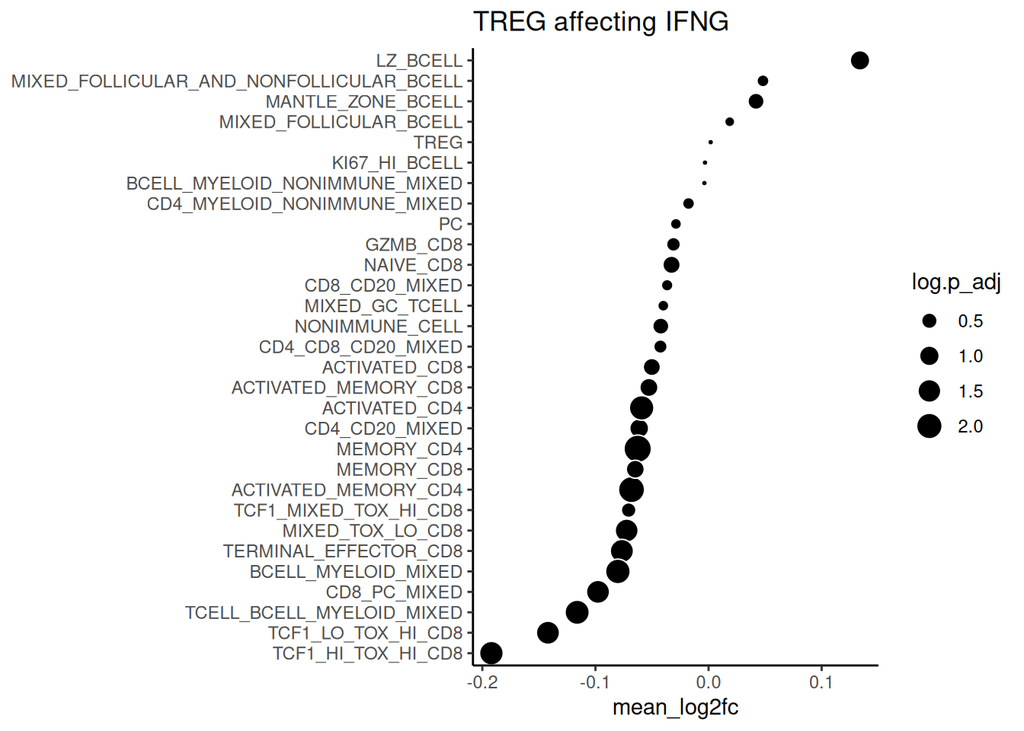

| feats | cell_type | mean_log2fc | p_value | Welch_t | p_adj | log.p_adj |
| --- | --- | --- | --- | --- | --- | --- |
| IFNG | CD4_CD20_MIXED | -0.061328114 | 0.066587619 | -1.98917806 | 0.125454934 | 0.90151225 |
| IFNG | PC | -0.028835847 | 0.582465746 | -0.56280971 | 0.690460914 | 0.16086090 |
| IFNG | MIXED_FOLLICULAR_AND_NONFOLLICULAR_BCELL | 0.048100229 | 0.495967493 | 0.69905601 | 0.610180827 | 0.21454144 |
| IFNG | CD8_PC_MIXED | -0.097759959 | 0.010832636 | -2.93644347 | 0.028353881 | 1.54738749 |
| IFNG | TCF1_HI_TOX_HI_CD8 | -0.191989777 | 0.007812812 | -3.10126009 | 0.022061627 | 1.65636247 |
| IFNG | MIXED_GC_TCELL | -0.040024020 | 0.582384917 | -0.56293168 | 0.690460914 | 0.16086090 |
| IFNG | CD4_CD8_CD20_MIXED | -0.042548906 | 0.373602719 | -0.91911022 | 0.485683535 | 0.31364662 |
| IFNG | BCELL_MYELOID_NONIMMUNE_MIXED | -0.003684448 | 0.934495149 | -0.08368061 | 0.956531936 | 0.01930053 |
| IFNG | CD4_MYELOID_NONIMMUNE_MIXED | -0.017710026 | 0.500704976 | -0.69125968 | 0.612147150 | 0.21314417 |
| IFNG | ACTIVATED_CD4 | -0.059164367 | 0.004970243 | -3.32869579 | 0.015166116 | 1.81912562 |

[output cut: 20 more lines]

```r
  ggsave(filename = 'output/icf.treg-effects-on-GZMB.across-celltypes.pdf', height=6, width=6)
plot.icf.affectCells(dt = icf.persample.regroup, probe.subset = "TREG",  probe.feature = "IFNG")
```

```r
  ggsave(filename = 'output/icf.treg-effects-on-IFNg.across-celltypes.pdf', height=6, width=6)
```

# 8 heatmap of the ICF

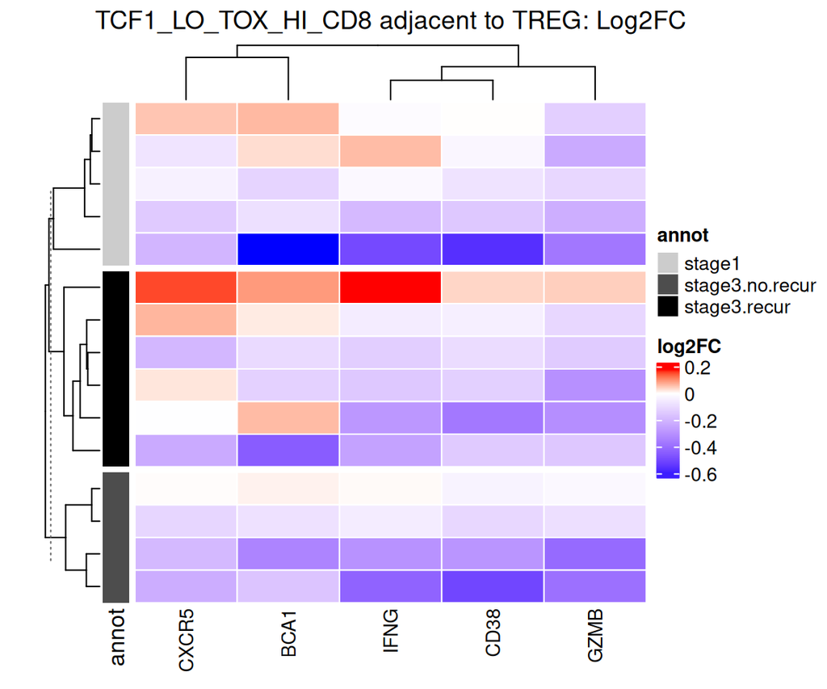

```r
index.cell = "TCF1_LO_TOX_HI_CD8"
interacting.cell = "TREG"
df.for.plot <- icf.persample.regroup[int_cell_type == interacting.cell & cell_type == index.cell]
annotation.df <- data.frame(list_ID = c(stage1.subgroup, recur.subgroup, norecur.subgroup))
annotation.df$annot <- c(rep("stage1", 5), rep("stage3.recur", length(recur.subgroup)),
                         rep("stage3.no.recur", length(norecur.subgroup)))
rownames(annotation.df) <- annotation.df$list_ID
annotation.df$list_ID <- NULL
heatmap.feats <- proteinsList # c("IFNG", "GZMB", "HLADR")
heatmap.matrix <- df.for.plot[feats %in% heatmap.feats, .(log2fc, feats, list_ID)]
heatmap.matrix <- (heatmap.matrix %>% pivot_wider(names_from = feats, values_from=log2fc, id_cols = list_ID)) %>%
   tibble::column_to_rownames("list_ID")
heatmap.matrix <- heatmap.matrix[rownames(annotation.df), c("GZMB","IFNG", "CD38", "CXCR5", "BCA1")] %>% as.matrix()
colors <- c("stage1" = "gray80", "stage3.no.recur" = "gray30", "stage3.recur" = "black")
ht.annot <- HeatmapAnnotation(df = annotation.df, col = list(annot = colors), which = "row")
col.fxn <- circlize::colorRamp2(c(min(as.vector(heatmap.matrix)), 0, max(as.vector(heatmap.matrix))), c("blue", "white", "red"))


# pdf('output/icf.selected.tcf1_lo-near-treg.heatmap.pdf', width=6, height=4)

Heatmap(  heatmap.matrix, name = "log2FC",
  row_split = annotation.df$annot, left_annotation = ht.annot, rect_gp = gpar(col = "white", lwd = 1),
  cluster_rows = TRUE, cluster_columns = TRUE, show_row_names = F, col = col.fxn,
  row_names_gp = gpar(fontsize = 10),  column_names_gp = gpar(fontsize = 10),
  column_title = (paste0(index.cell, " adjacent to ", interacting.cell, ": Log2FC")), row_title = " "
)
```

```r
# dev.off()
```

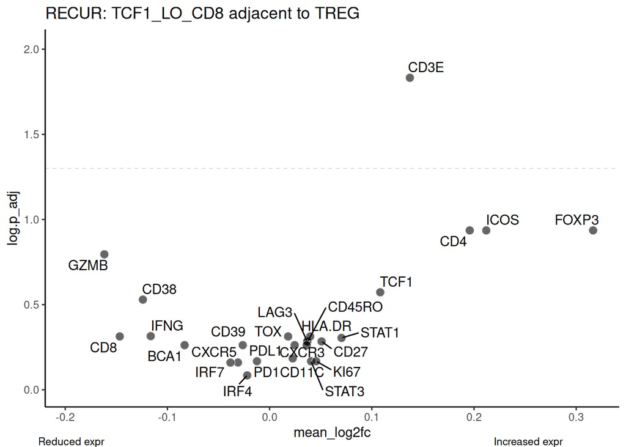

| feats | mean_sel | mean_other | mean_log2fc | p_value | Welch_t | p_adj | log.p_adj | highlight.feat |
| --- | --- | --- | --- | --- | --- | --- | --- | --- |
| GZMB | 6.082764 | 6.777615 | -0.16172052 | 0.030795180 | -2.9801338 | 0.16013493 | 0.79551391 | 0 |
| CD8 | 25.852187 | 29.179157 | -0.14666518 | 0.183078708 | -1.5446891 | 0.48618752 | 0.31319620 | 0 |
| CD38 | 6.757991 | 7.566086 | -0.12398483 | 0.079562197 | -2.1953133 | 0.29551673 | 0.52941793 | 0 |
| IFNG | 3.590624 | 3.865308 | -0.11633818 | 0.148963915 | -1.7047391 | 0.48413272 | 0.31503556 | 0 |
| BCA1 | 6.760516 | 6.708167 | -0.08319920 | 0.352655249 | -1.0243353 | 0.54689223 | 0.26209824 | 0 |
| IRF7 | 3.944928 | 4.111605 | -0.03831954 | 0.666107834 | -0.4580906 | 0.69275215 | 0.15942212 | 0 |
| CXCR5 | 6.628857 | 6.688638 | -0.03097389 | 0.638488174 | -0.4997114 | 0.69169552 | 0.16008504 | 0 |
| CD39 | 8.672935 | 8.772072 | -0.02630091 | 0.399652016 | -0.9202765 | 0.54689223 | 0.26209824 | 0 |
| IRF4 | 7.451114 | 8.112646 | -0.02194293 | 0.823086517 | -0.2356033 | 0.82308652 | 0.08455451 | 0 |
| PD1 | 1.606667 | 1.615365 | -0.01238927 | 0.584381788 | -0.5843079 | 0.67990205 | 0.16755365 | 0 |

[output cut: 16 more lines]

```r
plot.volcano.icf(dt = icf.persample.regroup[list_ID %in% recur.subgroup], receiver_cell = "TCF1_LO_TOX_HI_CD8",
                      sender_cell = "TREG", specific.title = "RECUR: TCF1_LO_CD8 adjacent to TREG")
```

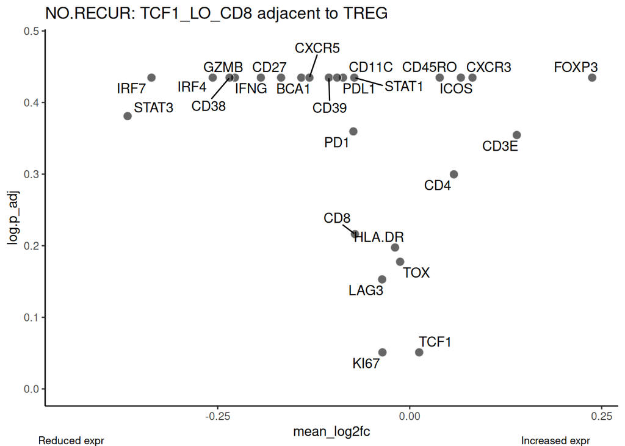

| feats | mean_sel | mean_other | mean_log2fc | p_value | Welch_t | p_adj | log.p_adj | highlight.feat |
| --- | --- | --- | --- | --- | --- | --- | --- | --- |
| STAT3 | 12.775086 | 13.019097 | -0.36737224 | 0.27190248 | -1.3427765 | 0.4158509 | 0.3810624 | 0 |
| IRF7 | 12.770701 | 13.350372 | -0.33627472 | 0.21248185 | -1.5788721 | 0.3674253 | 0.4348309 | 0 |
| IRF4 | 12.283860 | 12.846518 | -0.25651484 | 0.18969806 | -1.6895371 | 0.3674253 | 0.4348309 | 0 |
| CD38 | 9.076959 | 10.875612 | -0.23461297 | 0.11414158 | -2.2096245 | 0.3674253 | 0.4348309 | 0 |
| GZMB | 5.607047 | 6.646622 | -0.22763713 | 0.11126661 | -2.2370411 | 0.3674253 | 0.4348309 | 0 |
| IFNG | 5.329472 | 6.245327 | -0.19385854 | 0.15588950 | -1.8852147 | 0.3674253 | 0.4348309 | 0 |
| CD27 | 18.046657 | 19.899330 | -0.16755665 | 0.21121320 | -1.5846769 | 0.3674253 | 0.4348309 | 0 |
| BCA1 | 7.620570 | 8.489800 | -0.14121926 | 0.15248072 | -1.9076335 | 0.3674253 | 0.4348309 | 0 |
| CXCR5 | 6.072814 | 6.553987 | -0.13061176 | 0.08061958 | -2.5964969 | 0.3674253 | 0.4348309 | 0 |
| CD39 | 8.381174 | 9.144109 | -0.10532055 | 0.20289712 | -1.6237197 | 0.3674253 | 0.4348309 | 0 |

[output cut: 16 more lines]

```r
plot.volcano.icf(dt = icf.persample.regroup[list_ID %in% norecur.subgroup], receiver_cell = "TCF1_LO_TOX_HI_CD8",
                      sender_cell = "TREG", specific.title = "NO.RECUR: TCF1_LO_CD8 adjacent to TREG")
```

Just not enough resolution to see differences in recurrence vs no.recurrence even when Treg are grouped this way. Probably due to a combination of # cells and # biological replicates. Probably this analysis needs at least several hundred interacting cell pairs and at least 5 biological replicates at minimum